# CSC498H Project Phase I

Jalal El Zein & Tamer Kobba

# Introduction

# Data Exploration

Load the required libraries

```r
library(tidyverse)
```

```r
library(ggplot2)
library(polycor)
library(caret)
library(MASS)
library(cvms)
library(pROC)
```

Read the data from the CSV file

```r
data <- read.csv("DataAssign2.csv")
```

## Exploring the Structure of the Dataset

Display the structure of the dataset

```r
str(data)
```

```
## 'data.frame':    260 obs. of  7 variables:
##  $ V1: chr  "high" "high" "low" "high" ...
##  $ V2: chr  "med" "med" "med" "med" ...
##  $ V3: chr  "2" "4" "5more" "4" ...
##  $ V4: chr  "4" "4" "4" "more" ...
##  $ V5: chr  "med" "big" "small" "big" ...
##  $ V6: chr  "high" "high" "med" "high" ...
##  $ V7: chr  "bad" "bad" "bad" "bad" ...
```

## Summary of the Dataset

Provide a summary of the dataset

```r
summary(data)
```

```
##       V1                 V2                 V3                 V4
##  Length:260         Length:260         Length:260         Length:260
##  Class :character   Class :character   Class :character   Class :character
##  Mode  :character   Mode  :character   Mode  :character   Mode  :character
##       V5                 V6                 V7
##  Length:260         Length:260         Length:260
##  Class :character   Class :character   Class :character
##  Mode  :character   Mode  :character   Mode  :character
```

Let’s display the first few rows of the dataset

```r
head(data)
```

```
##     V1    V2    V3   V4    V5   V6  V7
## 1 high   med     2    4   med high bad
## 2 high   med     4    4   big high bad
## 3  low   med 5more    4 small  med bad
## 4 high   med     4 more   big high bad
## 5 high   med     4 more small high bad
## 6  med vhigh     4 more small high bad
```

We can also provide a concise summary of the dataset with the following

```r
glimpse(data)
```

```
## Rows: 260
## Columns: 7
## $ V1 <chr> "high", "high", "low", "high", "high", "med", "low", "high", "high"…
## $ V2 <chr> "med", "med", "med", "med", "med", "vhigh", "vhigh", "low", "high",…
## $ V3 <chr> "2", "4", "5more", "4", "4", "4", "3", "4", "5more", "3", "5more", …
## $ V4 <chr> "4", "4", "4", "more", "more", "more", "4", "more", "more", "more",…
## $ V5 <chr> "med", "big", "small", "big", "small", "small", "med", "small", "me…
## $ V6 <chr> "high", "high", "med", "high", "high", "high", "high", "high", "hig…
## $ V7 <chr> "bad", "bad", "bad", "bad", "bad", "bad", "bad", "bad", "bad", "bad…
```

## Explore Response Variable (V7)

### Unique Values in V7

```r
unique(data$V7)
```

```
## [1] "bad"  "good"
```

# Check for missing values in the dataset

```r
colSums(is.na(data))
```

```
## V1 V2 V3 V4 V5 V6 V7
##  0  0  0  0  0  0  0
```

# Display the proportion of each unique value in the response variable (V7)

```r
prop.table(table(data$V7))
```

```
##
##  bad good
##  0.5  0.5
```

## Categorical Variable Analysis

### Load Libraries and Read Data

Plot and Summarize Categorical Variables

```r
# Function to generate plot and summary for a categorical variable
plot_and_summary <- function(data, x_var, fill_var, y_var) { # Plot
  plot <- ggplot(data, aes_string(x = x_var, fill = fill_var)) +
    geom_bar() +
    labs(y = y_var, fill = "Acceptability")
  # Summary
  summary_table <- data %>%
    group_by_at(vars(x_var, fill_var)) %>%
    summarise(count = n()) %>%
    arrange(across(c(x_var, fill_var)))
  # Display the plot and return the summary table
  print(plot)
  return(summary_table)
}
```

## Display the plot and return the summary table

[output not shown]

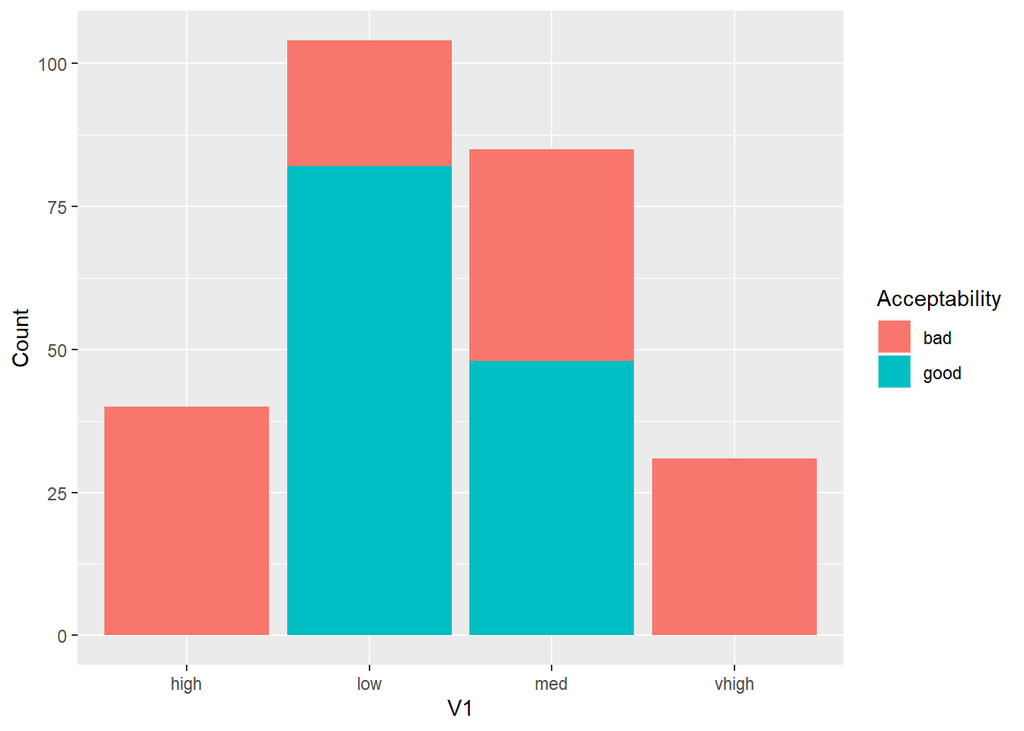

```
## argument.
```

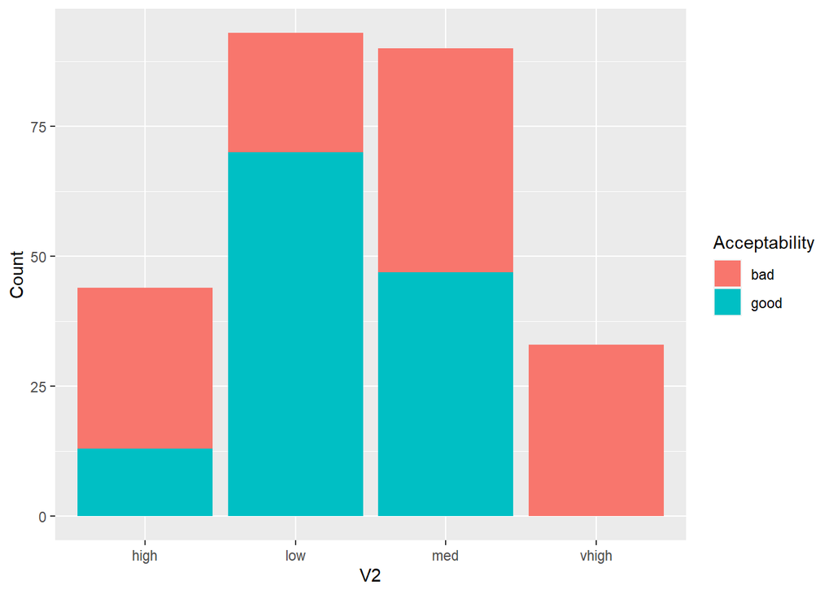

```
## argument.
```

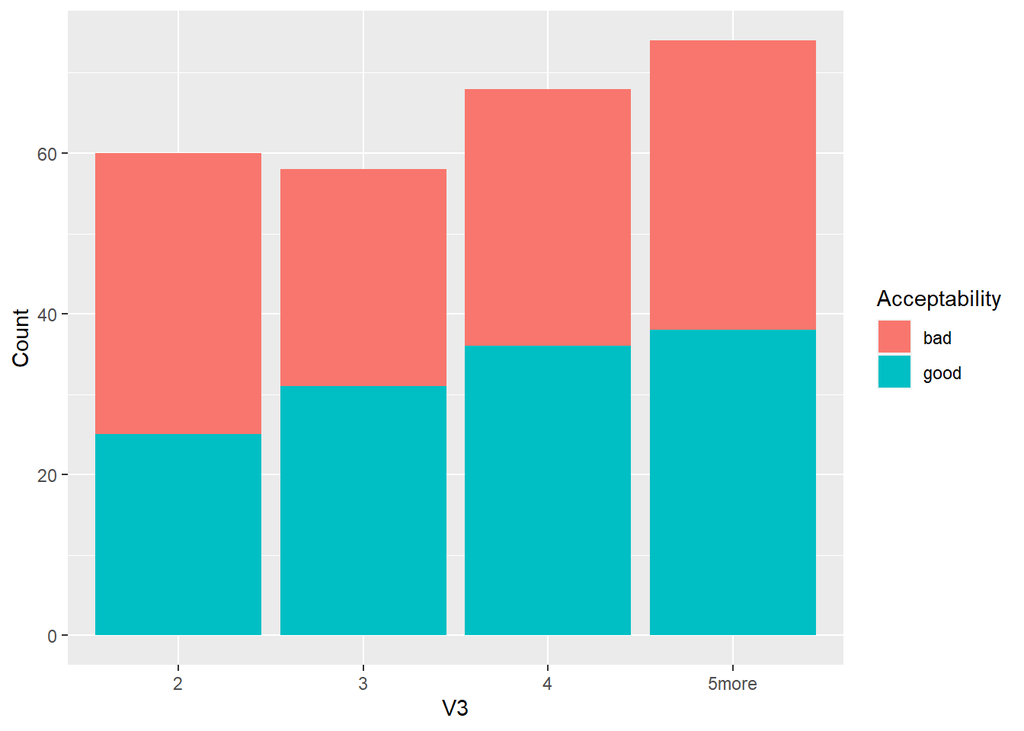

```
## argument.
```

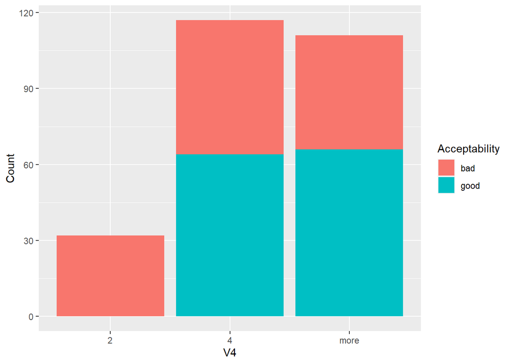

```
## argument.
```

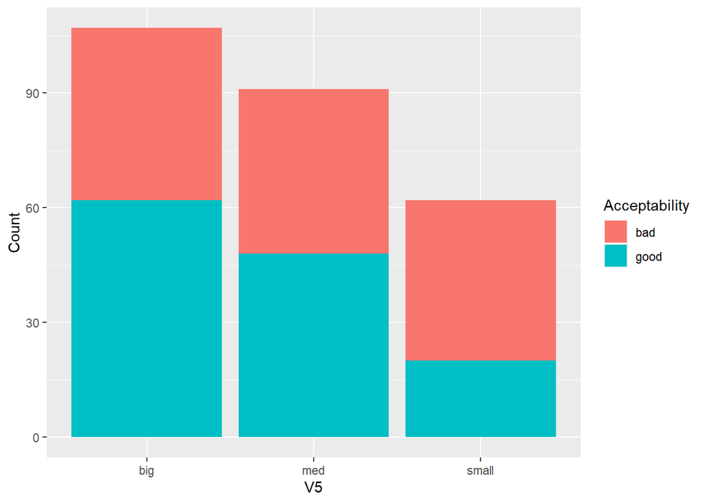

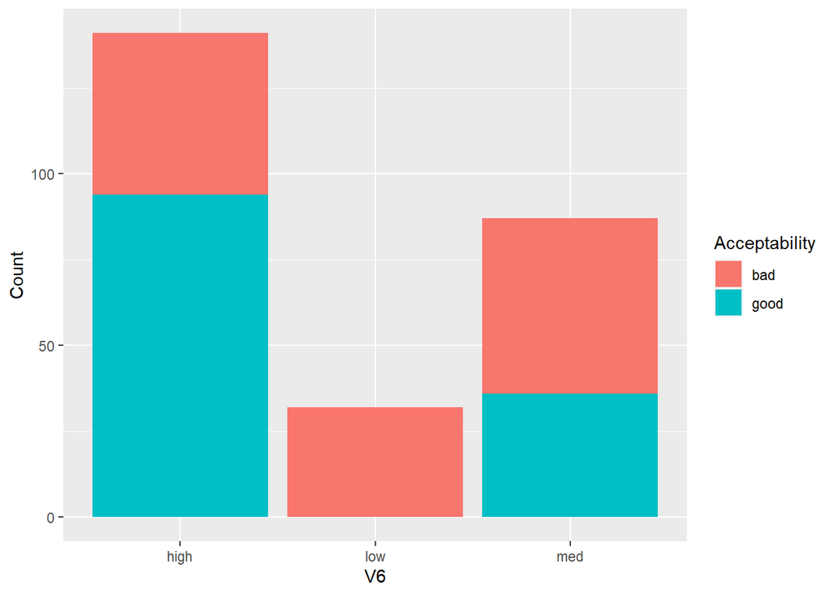

```r
# List of categorical variables
 categorical_vars <- c("V1", "V2", "V3", "V4", "V5", "V6")
# Apply the function for each variable
 results <- lapply(categorical_vars, function(var) {
plot_and_summary(data, var, "V7", "Count") })
```

```r
# Rename variables for better understanding
 colnames(data) <- c("Buying_Price", "Maintenance_Price", "Number_of_Doors", "Capacity", "Luggage_Boot_Size", "Estimated_Safety", "Acceptability")
# Convert all variables to factors data[] <- lapply(data, as.factor)
 # Explicitly set the order of levels for "Buying_Price"
data$Buying_Price <- factor(data$Buying_Price, levels = c("low", "med", "high", "vhigh"), ordered = TRUE)
# Calculate the correlation matrix using hector
 correlation_result <- hetcor(data)
```

```
## data contain one or more character variables
## the values of which are ordered alphabetically
```

```r
# Extract the correlation matrix
correlation_matrix <- correlation_result$correlations
# Convert the correlation matrix to a data frame for ggplot
correlation_df <- as.data.frame(as.table(correlation_matrix))
# Create a heatmap
heatmap_plot <- ggplot(data = correlation_df, aes(x = Var1, y = Var2, fill = Freq)) + geom_tile() + labs(title = "Categorical Variable Correlation Heatmap", x = "Variable 1", y = "Variable 2") + scale_fill_gradient2(low = "blue", mid = "white", high = "red", limits = c(-1, 1)) # Print the heatmap print(heatmap_plot)
```